# BIOS 7323 Lab 11

2018-11-26

### Objectives

Understand different representations of (Weibull) parametric survival analyses

### Data

The file liver.txt contains the data for 418 patients with primary biliary cirrhosis. Each row of the file corresponds to a single patient. (The first row of the file contains the variable names.) Dataset obtained from emersonstatistics.com.

### Parametric model forms

Let $X$ be the time to event and $Z$ a vector of fixed time explanatory variables.

> *Accelerated failure time (AFT) form*

$S(x|Z)=S_0(\exp(\theta'Z)x)$

where $\theta'=(\theta_1,\ldots,\theta_p)$ is a vector of regression coefficients

Survival of an individual with covariates $Z$ at time $x$ is the same as baseline survival at time $\exp(\theta'Z)x$. The term $\exp(\theta'Z)$ is called the acceleration factor.

> *Log-linear form*

In the log-linear form, if $W \sim$ standard extreme value distribution, then $X \sim$ Weibull. The model in this form is:

$\log X = Y = \mu +\gamma'z +\sigma W$

where $\gamma'=(\gamma_1,\ldots,\gamma_p)$ is a vector of regression coefficients and $W$ is the error random variable

If $S_0(x)$ is the survival function of the random variable $\exp(\mu+\sigma W)$ then the AFT and log-linear forms are equivalent with $\theta=-\gamma$. This means we can estimate parameters in the log-linear form and transform to interpret the covariates in AFT form.

> *Proportional hazards form*

The Weibull model also has a proportion hazards (PH) form:

$h(x|Z)=h_0(x)\exp(\beta'Z)=\alpha \lambda x^{\alpha-1}\exp(\beta'Z)$

The PH form is related to the log-linear form through the reparametrization:

$\alpha =\frac{1}{\sigma} \qquad \lambda=\exp(\frac{-\mu}{\sigma}) \qquad \beta_j=\frac{-\gamma_j}{\sigma},\; j=1,\ldots,p$

```r
#load the data
liver_dat<-read_table("liver.txt")
#keep only stage, death status, and observed time variables
liver<-select(liver_dat, obstime, status, stage) %>% remove_missing()
# fit a parametric Weibull regression with stage as the covariate using survreg(..., dist="weibull")
mod1 <- survreg(Surv(obstime,status) ~ factor(stage), data=liver, dist="weibull")

# Find the MLE of median survival for a patient with stage 1 primary biliary cirrhosis using predict(..., type="quantile", p=0.5, newdata=data.frame(stage=1))
(medsurv_1 <- predict(mod1, type="quantile", p=0.5, se=TRUE, newdata=data.frame(stage=1)) %>% unlist() )
```

```
##    fit.1 se.fit.1
## 21770.82 18290.97
```

```r
# What is the MLE of median survival for a patient with stage 4 primary biliary cirrhosis?
( medsurv_4 <- predict(mod1, type="quantile", p=0.5, se=TRUE, newdata=data.frame(stage=4)) %>% unlist() )
```

```
##     fit.1  se.fit.1
## 1765.2227  182.5302
```

```r
# get a summary of the model fit, note that the parameters are in the log-linear form
summary(mod1)
```

```
##
## Call:
## survreg(formula = Surv(obstime, status) ~ factor(stage), data = liver,
##     dist = "weibull")
##                  Value Std. Error     z      p
## (Intercept)    10.2915     0.8445 12.19 <2e-16
## factor(stage)2 -1.3022     0.8573 -1.52 0.1288
## factor(stage)3 -1.7509     0.8447 -2.07 0.0382
## factor(stage)4 -2.5123     0.8487 -2.96 0.0031
## Log(scale)     -0.1896     0.0761 -2.49 0.0127
##
## Scale= 0.827
##
## Weibull distribution
## Loglik(model)= -1162.3   Loglik(intercept only)= -1188.8
##  Chisq= 52.97 on 3 degrees of freedom, p= 1.9e-11
## Number of Newton-Raphson Iterations: 6
## n= 312
```

```r
# using the output from survreg() extract the estimates of mu (Intercept) and sigma (Scale)
mu <- coef(mod1)['(Intercept)']
sigma <- mod1$scale

# Now get the estimates for var(mu), var(sigma) and cov(mu,sigma)
# Note: the variance/covar matrix from survreg() has the variance of log(sigma), not sigma
# using delta-method:
#   var(sigma)=var(log(sigma))*sigma^2
#   cov(mu,sigma)=cov(mu,log(sigma))*sigma

varmu <- mod1$var['(Intercept)','(Intercept)']
varsigma <- mod1$var['Log(scale)','Log(scale)']*sigma^2
cvmusigma <- mod1$var['Log(scale)','(Intercept)']*sigma
```

```r
## Proportional Hazards form

# using the output from survreg() and the reparameterization above, get point estimates for
# lambda and alpha in the PH form

( lambda <- exp(-mu/sigma) )
```

```
##  (Intercept)
## 3.956577e-06
```

```r
( alpha <- 1/sigma )
```

```
## [1] 1.208773
```

```r
# now get the variance of alpha and lambda using K&M formulas (12.2.14) and (12.2.15)

( varlambda=exp(-2 * (mu/sigma)) * ((varmu/sigma^2) - (2 * (mu * cvmusigma)/sigma^3) + ((mu^2 * varsigma)/sigma^4)) )
```

```
##  (Intercept)
## 2.427324e-11
```

```r
( varalpha=varsigma/sigma^4 )
```

```
## [1] 0.008467292
```

```r
## Accelerated failure time form

# using the output from survreg() and the appropriate reparameterization, get the acceleration factors for stage 2, 3, and 4 compared to stage 1.

# How do you interpret the acceleration factor?

accel <- function(varno,fit) {
  accel.factor = exp(-fit$coef[varno])
  CI = exp(-fit$coef[varno] + c(-1, 1) * 1.96 * sqrt(mod1$var[varno, varno]))
return(data.frame=c(accel.factor,CI))
}

( accel.factors<-lapply(2:4, function(x) accel(x,mod1)) )
```

```
## [[1]]
## factor(stage)2
##      3.6774049      0.6851792     19.7368894
##
## [[2]]
## factor(stage)3
##       5.759980       1.100089      30.158792
##
## [[3]]
## factor(stage)4
##       12.33319        2.33691       65.08917
```

```r
#acceleration factor is change in survival for stage 1 vs. stage 4,
# time is moving 12.3 times faster for stage 4 vs. stage 1
# or equivalently median survival is 12.3 times longer for stage 1 vs. stage 4
medsurv_4[1]
```

```
##    fit.1
## 1765.223
```

```r
medsurv_4[1]*accel.factors[[3]][1]
```

```
##    fit.1
## 21770.82
```

```r
medsurv_1[1]
```

```
##    fit.1
## 21770.82
```

```r
## Use WeibullReg() in the SurvRegCensCov package to get estimates in PH form and AFT form
# and verify they match those calculated above

# Note: WeibullReg() uses the same parameterizations as K&M, but switches the names of some variables. For example, alpha=1/sigma in K&M is called gamma by WeibullReg(). see vignette("weibull")

(mod2 <- SurvRegCensCov::WeibullReg(Surv(obstime,status) ~ factor(stage), data=liver) )
```

```
## $formula
## Surv(obstime, status) ~ factor(stage)
##
## $coef
##                    Estimate           SE
## lambda         3.956577e-06 4.926788e-06
## gamma          1.208773e+00 9.201789e-02
## factor(stage)2 1.574073e+00 1.030862e+00
## factor(stage)3 2.116482e+00 1.011812e+00
## factor(stage)4 3.036793e+00 1.008403e+00
##
## $HR
##                       HR        LB        UB
## factor(stage)2  4.826266 0.6399405  36.39845
## factor(stage)3  8.301877 1.1426679  60.31601
## factor(stage)4 20.838304 2.8874064 150.38925
##
## $ETR
##                       ETR         LB        UB
## factor(stage)2 0.27193089 0.05066811 1.4594271
## factor(stage)3 0.17361172 0.03315884 0.9089894
## factor(stage)4 0.08108204 0.01536401 0.4279025
##
## $summary
##
## Call:
## survival::survreg(formula = formula, data = data, dist = "weibull")
##                  Value Std. Error     z      p
## (Intercept)    10.2915     0.8445 12.19 <2e-16
## factor(stage)2 -1.3022     0.8573 -1.52 0.1288
## factor(stage)3 -1.7509     0.8447 -2.07 0.0382
## factor(stage)4 -2.5123     0.8487 -2.96 0.0031
## Log(scale)     -0.1896     0.0761 -2.49 0.0127
##
## Scale= 0.827
##
## Weibull distribution
## Loglik(model)= -1162.3   Loglik(intercept only)= -1188.8
##  Chisq= 52.97 on 3 degrees of freedom, p= 1.9e-11
## Number of Newton-Raphson Iterations: 6
## n= 312
```

```r
# 1/ETR = Acceleration factor
accel.fact<-1/mod2$ETR
colnames(accel.fact) <-c("AF","UB","LB")
accel.fact
```

```
##                       AF       UB        LB
## factor(stage)2  3.677405 19.73628 0.6852004
## factor(stage)3  5.759980 30.15787 1.1001228
## factor(stage)4 12.333187 65.08718 2.3369810
```

#### Diagnostics

Cox-Snell residuals can be used to check the overall fit of the model. For the Weibull model the C-S residuals are:

$r_i = \hat{\lambda}\exp(\hat{\beta}'\mathbf{Z}_i)t_{i}^{\hat{\alpha}}$

If the model fits the data, a plot of $r_i$ vs. the Nelson-Aalen estimator of the cumulative hazard of the $r_i$’s should be a straight line with slope 1.

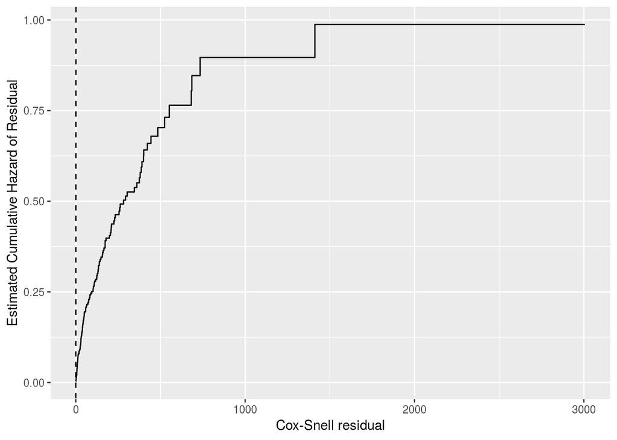

```r
# assess the overall fit of the Weibull model by producing a cumulative hazard plot for the Cox-Snell residuals (see K&M p. 414)

# reparameterization from log-linear to PH
betas <- -coef(mod1)[2:4]/sigma

#create Cox-Snell residuals
#cs_resid <- liver %>% mutate(betaZ=recode(stage,`1`=0,`2`=betas[1],`3`=betas[2],`4`=betas[3]),
#                 expbetaZ=exp(betaZ), coxsnell=lambda*expbetaZ*obstime^alpha)

cs_resid <- liver %>% mutate(betaZ=mod1$linear.predictors,                expbetaZ=exp(betaZ), coxsnell=lambda*expbetaZ*obstime^alpha)

#use survfit with C-S residuals in place of time
residfit <- survfit(Surv(coxsnell,status)~1,type="fleming-harrington",data=cs_resid)

#transform to get N-A cumulative hazard for residuals
cs_dat <- data.frame(residfit[["time"]],residfit[["surv"]]) %>% as.tibble() %>%
  rename(csres=residfit...time..., surv=residfit...surv...) %>%
  mutate(cumhaz=-log(surv))

ggplot(cs_dat,aes(x=csres,y=cumhaz))+geom_step()+geom_abline(slope=1,intercept=0,lty=2)+
  labs(x="Cox-Snell residual",y="Estimated Cumulative Hazard of Residual")
```

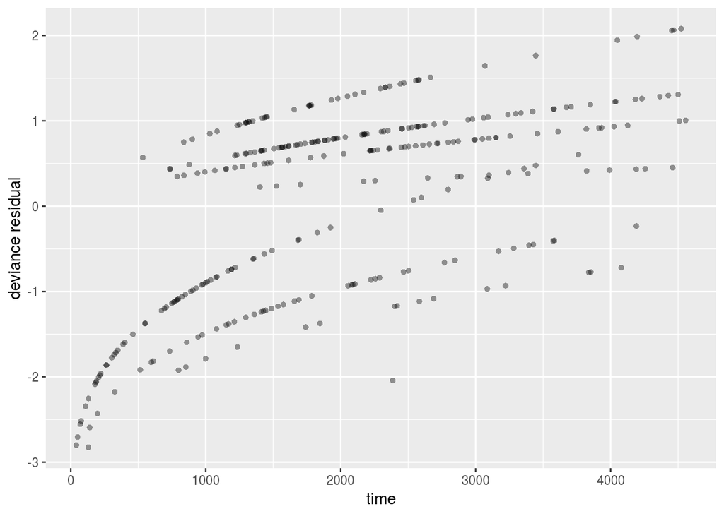

```r
# Does the Weibull model fit well?


#make a plot of deviance residuals vs. time
#based on this plot is the model adequate?

dev_dat<-data.frame(dr=resid(mod1,type="deviance"),time=liver$obstime) %>% as.tibble()

ggplot(dev_dat,aes(x=time,y=dr))+geom_point(alpha=0.4,shape=16)+labs(y="deviance residual")
```